# Homework 3

Lawson Busch

9/20/2018

```r
library(ggplot2)
library(dplyr)
library(ggridges)
joy <- read.csv("https://www.macalester.edu/~ajohns24/data/joy_division.csv")
```

## Excercise 1

### 1a)

```r
joy_pop <- joy %>%
  arrange(desc(track_popularity))
head(joy_pop)
```

```
##          album_name album_release_date
## 1 Unknown Pleasures         1979-06-01
## 2 Unknown Pleasures         1979-06-01
## 3 Unknown Pleasures         1979-06-01
## 4 Unknown Pleasures         1979-06-01
## 5            Closer               1980
## 6 Unknown Pleasures         1979-06-01
##                                     track_name track_number danceability
## 1           Disorder - 2007 Remastered Version            1        0.320
## 2 She's Lost Control - 2007 Remastered Version            6        0.485
## 3         Shadowplay - 2007 Remastered Version            7        0.433
## 4     New Dawn Fades - 2007 Remastered Version            5        0.387
## 5          Isolation - 2007 Remastered Version            2        0.544
## 6   Day Of The Lords - 2007 Remastered Version            2        0.317
##   energy loudness  mode speechiness acousticness instrumentalness liveness
## 1  0.798   -7.078 minor      0.1240     0.000330          0.69200   0.1760
## 2  0.846   -7.630 minor      0.0528     0.015700          0.02870   0.0766
## 3  0.756   -7.855 major      0.0565     0.000997          0.76100   0.1240
## 4  0.525   -9.634 major      0.0350     0.002360          0.76900   0.2510
## 5  0.783   -8.120 major      0.0540     0.048000          0.00734   0.0917
## 6  0.599   -8.434 major      0.0321     0.000019          0.89700   0.1220
##   valence   tempo duration_ms track_popularity
## 1   0.740  84.696      209040               63
## 2   0.743 144.246      237013               59
## 3   0.117 145.443      233720               56
## 4   0.258  78.339      291706               52
## 5   0.697 151.522      175093               51
## 6   0.113 124.492      287573               51
```

```r
joy_least <- joy %>%
  arrange(track_popularity)
head(joy_least)
```

```
##          album_name album_release_date        track_name track_number
## 1 Les Bains Douches         2007-03-28            Colony           15
## 2 Les Bains Douches         2007-03-28            Warsaw           14
## 3 Les Bains Douches         2007-03-28    Heart and Soul           13
## 4 Les Bains Douches         2007-03-28        Wilderness           10
## 5 Les Bains Douches         2007-03-28 A Means to an End            9
## 6 Les Bains Douches         2007-03-28    New Dawn Fades           11
##   danceability energy loudness  mode speechiness acousticness
## 1        0.359  0.752  -12.768 major      0.2890     0.102000
## 2        0.377  0.874  -13.055 minor      0.0917     0.075700
## 3        0.219  0.681   -8.960 major      0.0623     0.000131
## 4        0.494  0.516  -16.306 minor      0.0646     0.151000
## 5        0.369  0.755  -15.781 minor      0.0498     0.000118
## 6        0.342  0.463  -17.039 major      0.0452     0.329000
##   instrumentalness liveness valence   tempo duration_ms track_popularity
## 1            0.862    0.116   0.692 143.950      239547               24
## 2            0.959    0.361   0.273 166.396      161027               26
## 3            0.342    0.680   0.366  83.152      219440               28
## 4            0.770    0.120   0.775 119.634      166240               29
## 5            0.775    0.521   0.407 130.093      257347               30
## 6            0.851    0.118   0.345 152.029      278787               30
```

The most popular Joy Division track on Spotify is Disorder - 2007 Remastered Version, and the least popular Joy Division track on Spotify is Colony.

### 1b)

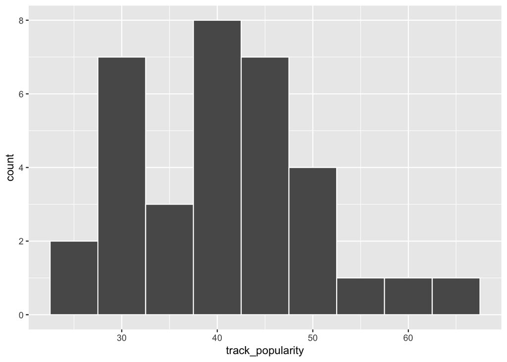

```r
ggplot(joy, aes(x = track_popularity)) + geom_histogram(binwidth=5, color = 'white')
```

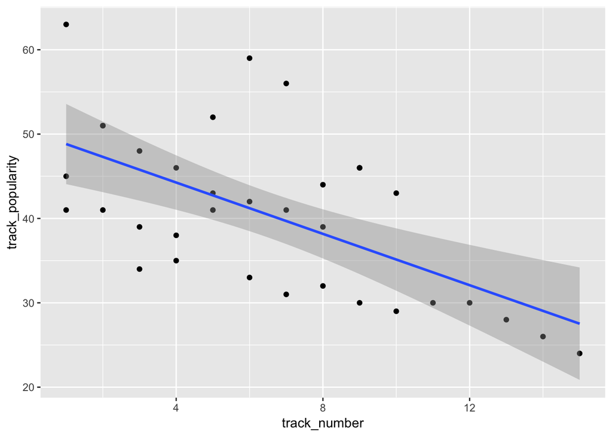

```r
ggplot(joy, aes(x = track_number, y = track_popularity)) + geom_point() + geom_smooth(method = 'lm')
```

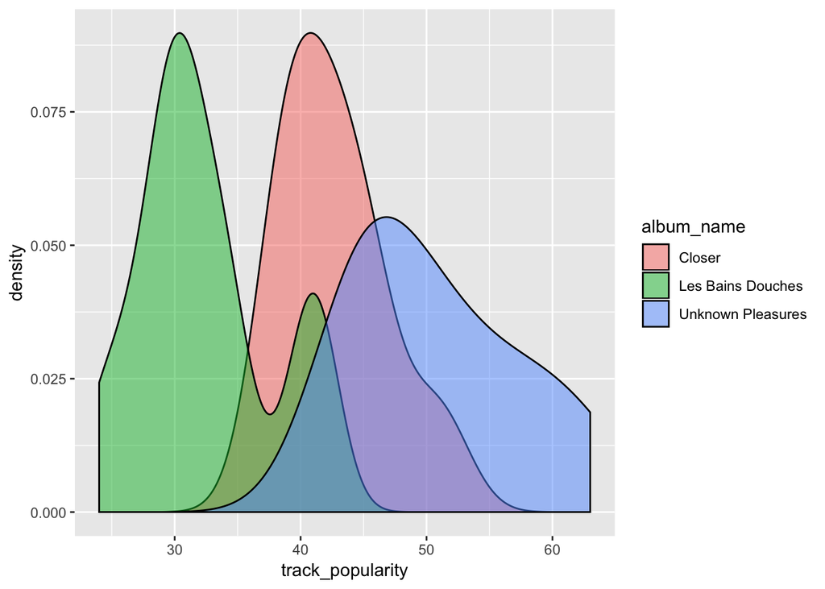

```r
ggplot(joy, aes(x = track_popularity, fill = album_name)) + geom_density(alpha = 0.5)
```

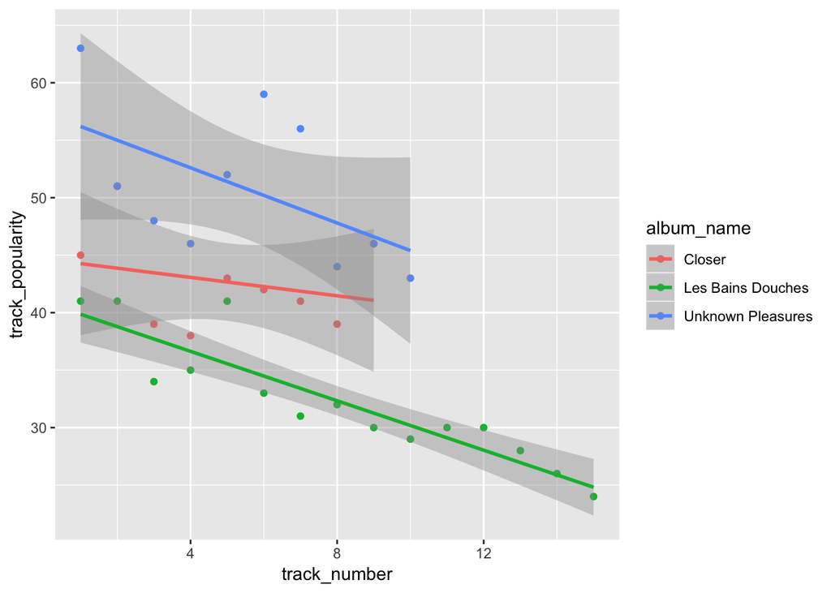

```r
ggplot(joy, aes(x = track_number, y = track_popularity, color = album_name)) + geom_point() + geom_smooth(method = 'lm')
```

### 1c)

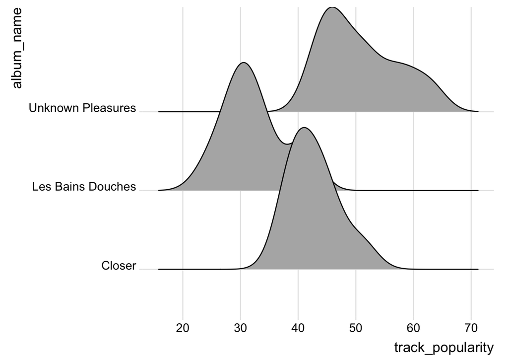

```r
ggplot(joy, aes(x = track_popularity, y = album_name)) +
    geom_density_ridges() +
    theme_ridges()
```

## Excercise 2

```r
joy_2 <- joy %>%
  select(-album_name, -album_release_date, -track_name)
head(joy_2)
```

```
##   track_number danceability energy loudness  mode speechiness acousticness
## 1            1        0.565  0.767   -7.348 major      0.0520      0.00645
## 2            2        0.544  0.783   -8.120 major      0.0540      0.04800
## 3            3        0.773  0.577  -11.936 major      0.0419      0.04950
## 4            4        0.600  0.880   -7.292 major      0.0445      0.00559
## 5            5        0.655  0.786   -7.946 minor      0.0287      0.03890
## 6            6        0.640  0.611   -9.817 major      0.0284      0.21100
##   instrumentalness liveness valence   tempo duration_ms track_popularity
## 1          0.04380   0.0765   0.787 126.435      364760               45
## 2          0.00734   0.0917   0.697 151.522      175093               51
## 3          0.01540   0.0543   0.941 127.977      285000               39
## 4          0.46000   0.6560   0.808 137.612      235053               38
## 5          0.57600   0.0527   0.752 130.549      249000               43
## 6          0.75600   0.0942   0.680 149.774      353106               42
```

```r
dim(joy_2)
```

```
## [1] 34 13
```

## Excercise 3

```r
library(leaps)
```

### 3a)

```r
#Do backward stepwise selection for all 12 possible predictors
back_step <- regsubsets(track_popularity ~ ., joy_2, method = "backward", nvmax = 12)
# Store the summary information
back_summary <- summary(back_step)
back_summary
```

```
## Subset selection object
## Call: regsubsets.formula(track_popularity ~ ., joy_2, method = "backward",
##     nvmax = 12)
## 12 Variables  (and intercept)
##                  Forced in Forced out
## track_number         FALSE      FALSE
## danceability         FALSE      FALSE
## energy               FALSE      FALSE
## loudness             FALSE      FALSE
## modeminor            FALSE      FALSE
## speechiness          FALSE      FALSE
## acousticness         FALSE      FALSE
## instrumentalness     FALSE      FALSE
## liveness             FALSE      FALSE
## valence              FALSE      FALSE
## tempo                FALSE      FALSE
## duration_ms          FALSE      FALSE
## 1 subsets of each size up to 12
## Selection Algorithm: backward
##           track_number danceability energy loudness modeminor speechiness
## 1  ( 1 )  " "          " "          " "    "*"      " "       " "
## 2  ( 1 )  "*"          " "          " "    "*"      " "       " "
## 3  ( 1 )  "*"          " "          " "    "*"      " "       " "
## 4  ( 1 )  "*"          " "          " "    "*"      " "       " "
## 5  ( 1 )  "*"          " "          " "    "*"      "*"       " "
## 6  ( 1 )  "*"          " "          "*"    "*"      "*"       " "
## 7  ( 1 )  "*"          "*"          "*"    "*"      "*"       " "
## 8  ( 1 )  "*"          "*"          "*"    "*"      "*"       " "
## 9  ( 1 )  "*"          "*"          "*"    "*"      "*"       " "
## 10  ( 1 ) "*"          "*"          "*"    "*"      "*"       "*"
## 11  ( 1 ) "*"          "*"          "*"    "*"      "*"       "*"
## 12  ( 1 ) "*"          "*"          "*"    "*"      "*"       "*"
##           acousticness instrumentalness liveness valence tempo duration_ms
## 1  ( 1 )  " "          " "              " "      " "     " "   " "
## 2  ( 1 )  " "          " "              " "      " "     " "   " "
## 3  ( 1 )  " "          " "              "*"      " "     " "   " "
## 4  ( 1 )  " "          " "              "*"      "*"     " "   " "
## 5  ( 1 )  " "          " "              "*"      "*"     " "   " "
## 6  ( 1 )  " "          " "              "*"      "*"     " "   " "
## 7  ( 1 )  " "          " "              "*"      "*"     " "   " "
## 8  ( 1 )  "*"          " "              "*"      "*"     " "   " "
## 9  ( 1 )  "*"          " "              "*"      "*"     "*"   " "
## 10  ( 1 ) "*"          " "              "*"      "*"     "*"   " "
## 11  ( 1 ) "*"          "*"              "*"      "*"     "*"   " "
## 12  ( 1 ) "*"          "*"              "*"      "*"     "*"   "*"
```

A plot of the adjusted $R^2$ values for the backward stepwise selection models.

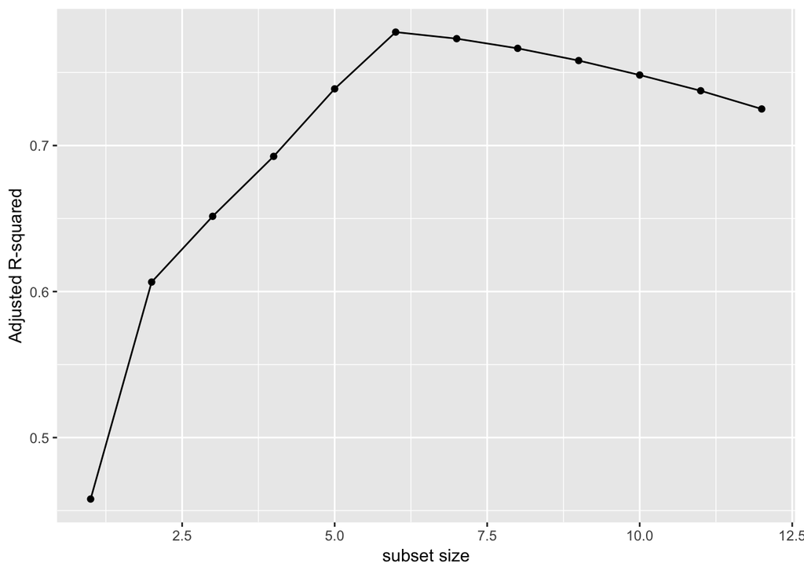

```r
plot_data <- data.frame(size = 1:12, adjr2 = back_summary$adjr2)
ggplot(plot_data, aes(x = size, y = adjr2)) +
    geom_point() +
    geom_line() +
    labs(x="subset size", y="Adjusted R-squared")
```

I would say that the optimal subset selection is with six predictor values, as that is both the last added predictor where we see a significant increase in adjusted $R^2$ value and is the last predictor before the drop off in adjusted $R^2$ value begins. While you could argue for a simpler model, I think the increase in adjusted $R^2$ is worth the additional predictors up until the sixth predictor.

```r
coef(back_step, 6)
```

```
##  (Intercept) track_number       energy     loudness    modeminor
##    87.191704    -1.032448   -12.904363     2.235056     5.242238
##     liveness      valence
##   -12.439237    -9.339314
```

The six predictors used for this subset are track_number, energy, loudness, modeminor, liveness, and valence.

## Excercise 4

### Excercise 4a)

```r
# Perform best subsets
best_subsets <- regsubsets(track_popularity ~ ., joy_2, nvmax = 12)

# Store the summary information
best_summary <- summary(best_subsets)
best_summary
```

```
## Subset selection object
## Call: regsubsets.formula(track_popularity ~ ., joy_2, nvmax = 12)
## 12 Variables  (and intercept)
##                  Forced in Forced out
## track_number         FALSE      FALSE
## danceability         FALSE      FALSE
## energy               FALSE      FALSE
## loudness             FALSE      FALSE
## modeminor            FALSE      FALSE
## speechiness          FALSE      FALSE
## acousticness         FALSE      FALSE
## instrumentalness     FALSE      FALSE
## liveness             FALSE      FALSE
## valence              FALSE      FALSE
## tempo                FALSE      FALSE
## duration_ms          FALSE      FALSE
## 1 subsets of each size up to 12
## Selection Algorithm: exhaustive
##           track_number danceability energy loudness modeminor speechiness
## 1  ( 1 )  " "          " "          " "    "*"      " "       " "
## 2  ( 1 )  "*"          " "          " "    "*"      " "       " "
## 3  ( 1 )  "*"          " "          "*"    "*"      " "       " "
## 4  ( 1 )  "*"          " "          "*"    "*"      "*"       " "
## 5  ( 1 )  "*"          " "          " "    "*"      "*"       " "
## 6  ( 1 )  "*"          " "          "*"    "*"      "*"       " "
## 7  ( 1 )  "*"          "*"          "*"    "*"      "*"       " "
## 8  ( 1 )  "*"          "*"          "*"    "*"      "*"       " "
## 9  ( 1 )  "*"          "*"          "*"    "*"      "*"       " "
## 10  ( 1 ) "*"          "*"          "*"    "*"      "*"       "*"
## 11  ( 1 ) "*"          "*"          "*"    "*"      "*"       "*"
## 12  ( 1 ) "*"          "*"          "*"    "*"      "*"       "*"
##           acousticness instrumentalness liveness valence tempo duration_ms
## 1  ( 1 )  " "          " "              " "      " "     " "   " "
## 2  ( 1 )  " "          " "              " "      " "     " "   " "
## 3  ( 1 )  " "          " "              " "      " "     " "   " "
## 4  ( 1 )  " "          " "              " "      " "     " "   " "
## 5  ( 1 )  " "          " "              "*"      "*"     " "   " "
## 6  ( 1 )  " "          " "              "*"      "*"     " "   " "
## 7  ( 1 )  " "          " "              "*"      "*"     " "   " "
## 8  ( 1 )  "*"          " "              "*"      "*"     " "   " "
## 9  ( 1 )  "*"          " "              "*"      "*"     "*"   " "
## 10  ( 1 ) "*"          " "              "*"      "*"     "*"   " "
## 11  ( 1 ) "*"          "*"              "*"      "*"     "*"   " "
## 12  ( 1 ) "*"          "*"              "*"      "*"     "*"   "*"
```

And a plot of our adjusted $R^2$ values for best subset selection:

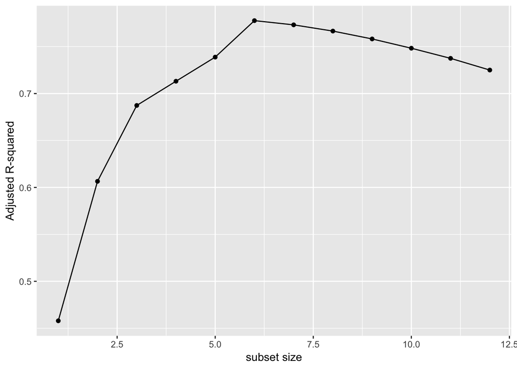

```r
plot_data <- data.frame(size = 1:12, adjr2 = best_summary$adjr2)
ggplot(plot_data, aes(x = size, y = adjr2)) +
    geom_point() +
    geom_line() +
    labs(x="subset size", y="Adjusted R-squared")
```

### 4b)

From the above plot, we can again see that the optimal subset size is 6 predictors, as it is the last significant increase in adjusted $R^2$ value, and we can see that after this increase, the adjusted $R^2$ values actually begin to drop off again.

```r
coef(best_subsets, 6)
```

```
##  (Intercept) track_number       energy     loudness    modeminor
##    87.191704    -1.032448   -12.904363     2.235056     5.242238
##     liveness      valence
##   -12.439237    -9.339314
```

We can see that the six predictors included in the model are track_number, energy, loudness, modeminor, liveness, and valence, which are the exact same predictors found by the backward stepwise method.

### 4c)

The optimal subsets chosen by the backward stepwise and the best subset procedures agree, as they are the exact same subsets with the same adjusted $R^2$ value.

## Excercise 5

### 5a)

```r
joy_model <- lm(track_popularity ~ track_number + energy + loudness + mode + liveness + valence, joy_2)
summary(joy_model)
```

```
##
## Call:
## lm(formula = track_popularity ~ track_number + energy + loudness +
##     mode + liveness + valence, data = joy_2)
##
## Residuals:
##     Min      1Q  Median      3Q     Max
## -8.6904 -2.1905  0.7296  2.6682  8.6233
##
## Coefficients:
##              Estimate Std. Error t value Pr(>|t|)
## (Intercept)   87.1917     5.5395  15.740 3.99e-15 ***
## track_number  -1.0324     0.2259  -4.571 9.66e-05 ***
## energy       -12.9044     5.3145  -2.428   0.0221 *
## loudness       2.2351     0.2998   7.455 5.09e-08 ***
## modeminor      5.2422     1.9089   2.746   0.0106 *
## liveness     -12.4392     5.0833  -2.447   0.0212 *
## valence       -9.3393     3.5414  -2.637   0.0137 *
## ---
## Signif. codes:  0 '***' 0.001 '**' 0.01 '*' 0.05 '.' 0.1 ' ' 1
##
## Residual standard error: 4.526 on 27 degrees of freedom
## Multiple R-squared:  0.8181, Adjusted R-squared:  0.7777
## F-statistic: 20.24 on 6 and 27 DF,  p-value: 7.888e-09
```

The estimated model formula is:

### 5b)

To write the most popular song possible, joy divison should primarily focus on putting the track early in the album (low track_number) and making it as loud as possible (high loudness). These two predictors should be focused on as they are the most statistically significant (assuming all other factors held constant). Then, Joy Division should focus on minimizing energy, liveness, and valence, while maximizing modeminor (again assuming all other factors are constant when adjusting the value for one predictor).

## Excercise 6

### 6b)

My loop to calculate LOOCV for my model:

```r
mspe_total = rep(0, 34)
for(i in 1:34) {
  train <- joy_2[-i,]
  test <- joy_2[i,]

  model_train <- lm(track_popularity ~ track_number + energy + loudness + mode + liveness + valence, train)
  model_test <- predict(model_train, newdata = data.frame(track_number = test$track_number, energy = test$energy,
                                                          loudness = test$loudness, mode = test$mode, liveness = test$liveness,
                                                          valence = test$valence))

  test_observed <- test$track_popularity
  test_residuals <- test_observed - model_test

  mspe_test = mean(test_residuals^2)
  mspe_total[i] = mspe_test
}

loocv = mean(mspe_total)
loocv
```

```
## [1] 28.09633
```

And checking using the cv.glm function:

```r
library(boot)
joy_model_glm <- glm(track_popularity ~ track_number + energy + loudness + mode + liveness + valence, joy_2, family = "gaussian")
joy_model_cv <- cv.glm(joy_2, joy_model_glm)
joy_model_cv$delta
```

```
## [1] 28.09633 27.89480
```

And we can see that my loop produces the correct LOOCV.

### 6d)

This model meets the independance assumption because the observations for each track do not depend on the observations for any other track.

First to check the observation of trend and homoskedasticity we can plot the residuals of the model against the predictions:

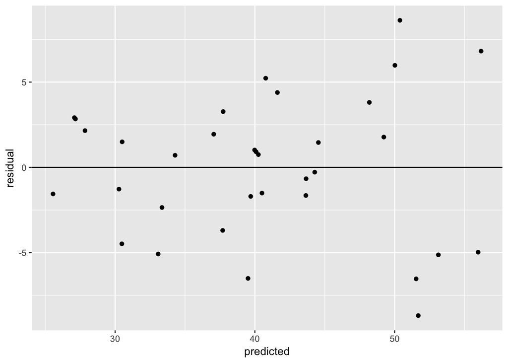

```r
joy_output <- data.frame(
  predicted = joy_model$fitted,
  residual = joy_model$residuals)

ggplot(joy_output, aes(y = residual, x = predicted)) +
    geom_point() +
    geom_hline(yintercept = 0)
```

To check the assumption of normality we can create a q-q plot of the residuals:

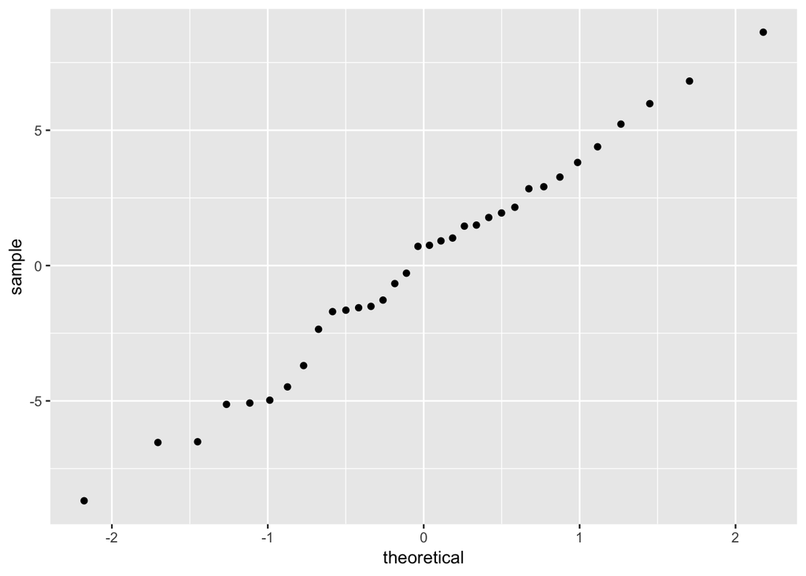

```r
# Q-Q plot of residuals
ggplot(joy_output, aes(sample = residual)) +
    geom_qq()
```

And from this output we can see that the assumption of normality also holds for this model, as the points roughly resemble a strait line, which is what we would expect if normality holds true.

## Excercise 7

### 7a)

```r
set.seed(2018)
library(glmnet)
joy_2 %>% na.omit(joy_2)
```

[output not shown]

[output cut: 90 more lines]

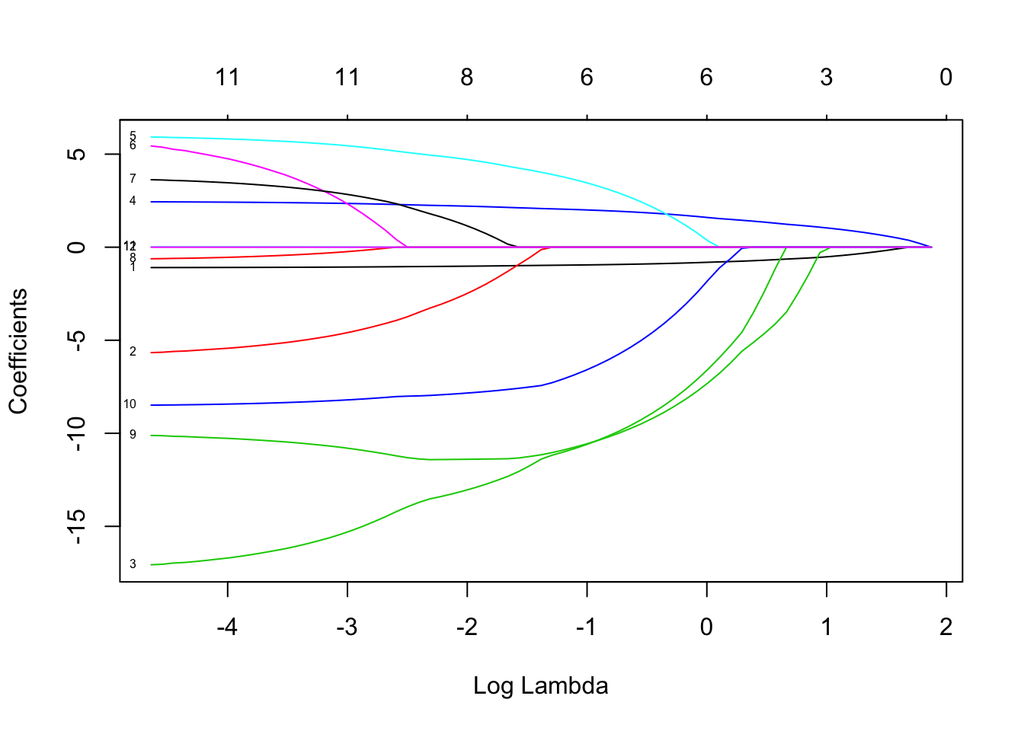

```r
# First process the data!
x <- model.matrix(track_popularity ~ ., joy_2)[,-1]
y <- joy_2$track_popularity

# Fit the LASSO for a grid of lambda
lasso_mod <- glmnet(x, y, alpha = 1)

# Plot a summary of these models
plot(lasso_mod, xvar = "lambda", label = TRUE)
```

### 7b)

Looking at the above plot, if we used a $log \lambda = 1$, then we would have $3$ predictors remaining in the model.

### 7c)

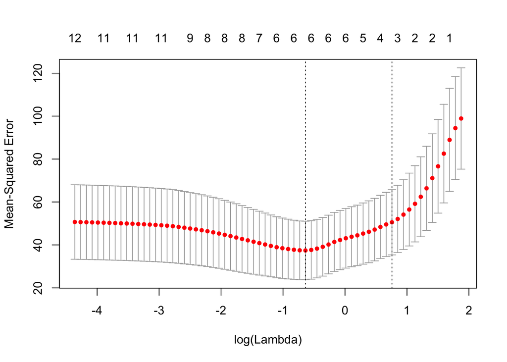

```r
set.seed(2018)

# Calculate the CV error rate for the LASSOs at each lambda
lasso_cv <- cv.glmnet(x, y, alpha = 1)

# Plot the CV results
plot(lasso_cv)
```

In this plot we see the cv value dip initially as we begin to eliminate predictors with higher lambda values. At a certain point, as we continue to eliminate predictors, our model becomes less accurate (hence a higher cv value), but we remove more predictors, so the trade off is that the model is simpler. Another reason that the cv begins to increase is that as we increase the lambda value, our coefficients shrink further, allowing for more residual error.

## Excercise 8

### 8a)

```r
lambda_best <- lasso_cv$lambda.min
lambda_best
```

```
## [1] 0.5282913
```

```r
log(lambda_best)
```

```
## [1] -0.6381074
```

The exact lambda for which the LASSO CV error is minimized is 0.5282913. We also see that the log of this value matches what we would expect it to be from the aboce plot.

### 8b)

```r
# Grab the coefficients for the LASSO using this lambda
lasso_coef <- predict(lasso_mod, type = "coefficients", s = lambda_best)
lasso_coef
```

```
## 13 x 1 sparse Matrix of class "dgCMatrix"
##                           1
## (Intercept)      78.5172511
## track_number     -0.9162792
## danceability      .
## energy           -9.5855032
## loudness          1.8993172
## modeminor         2.6764811
## speechiness       .
## acousticness      .
## instrumentalness  .
## liveness         -9.7438444
## valence          -5.3818557
## tempo             .
## duration_ms       .
```

The estimated model formula for the LASSO method is:

$$trackpopularity = 78.51 -0.91*tracknumber-9.58*energy+1.89*loudness+2.67*modeminor-9.74*liveness-5.38*valence$$

### 8c)

All of the variables in this model overlap with the variables in my final subsets model. However, when looking at the coefficients, we see that while all of the signs are the same, the values for every coefficient are shrunk. This makes sense, as the LASSO method is a shrinkage and selection method. So the shrunk coefficients are what we would expect to see.